# HumanActivityRecognitionProject

### 2. Random Forest

```r
rf <- randomForest(classe ~ ., data = myTraining)
# rf <- train(classe ~ ., data=myTraining, method='rf',prox=TRUE,ntree=500)
# head(getTree(rf$finalModel,k=2))
predrf <- predict(rf, newdata = myValidation)
confusionMatrix(predrf, myValidation$classe)
```

Confusion Matrix and Statistics

```
      Reference
```

Prediction A B C D E A 1395 1 0 0 0 B 0 948 0 0 0 C 0 0 855 2 0 D 0 0 0 802 0 E 0 0 0 0 901

Overall Statistics

```
           Accuracy : 0.9994
             95% CI : (0.9982, 0.9999)
No Information Rate : 0.2845
P-Value [Acc > NIR] : < 2.2e-16

              Kappa : 0.9992
```

Mcnemar’s Test P-Value : NA

Statistics by Class:

```
                 Class: A Class: B Class: C Class: D Class: E
```

Sensitivity 1.0000 0.9989 1.0000 0.9975 1.0000 Specificity 0.9997 1.0000 0.9995 1.0000 1.0000 Pos Pred Value 0.9993 1.0000 0.9977 1.0000 1.0000 Neg Pred Value 1.0000 0.9997 1.0000 0.9995 1.0000 Prevalence 0.2845 0.1935 0.1743 0.1639 0.1837 Detection Rate 0.2845 0.1933 0.1743 0.1635 0.1837 Detection Prevalence 0.2847 0.1933 0.1748 0.1635 0.1837 Balanced Accuracy 0.9999 0.9995 0.9998 0.9988 1.0000

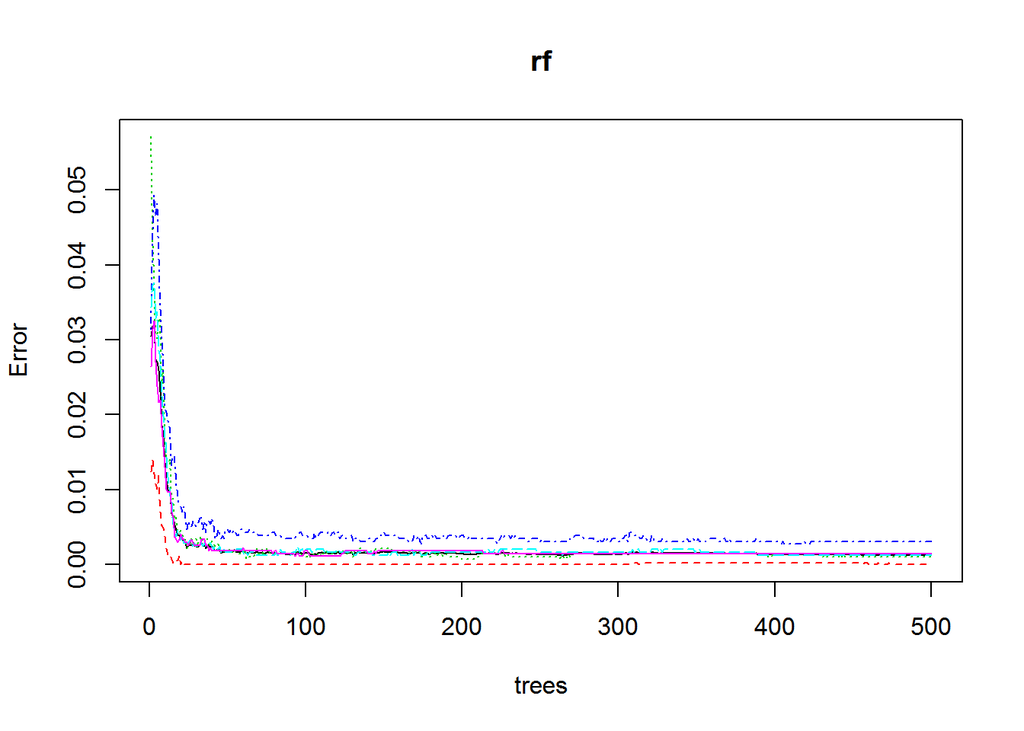

```r
plot(rf)
```

### 3. Gradient Boosting

```r
fitControl <- trainControl(method = "repeatedcv", number = 5, repeats = 1)
gbm <- train(classe ~ ., data = myTraining, method = "gbm", trControl = fitControl,
    verbose = FALSE)
predgbm <- predict(gbm, newdata = myValidation)
confusionMatrix(predgbm, myValidation$classe)
```

Confusion Matrix and Statistics

```
      Reference
```

Prediction A B C D E A 1395 2 0 0 0 B 0 941 1 0 0 C 0 5 846 1 0 D 0 1 8 803 2 E 0 0 0 0 899

Overall Statistics

```
           Accuracy : 0.9959
             95% CI : (0.9937, 0.9975)
No Information Rate : 0.2845
P-Value [Acc > NIR] : < 2.2e-16

              Kappa : 0.9948
```

Mcnemar’s Test P-Value : NA

Statistics by Class:

```
                 Class: A Class: B Class: C Class: D Class: E
```

Sensitivity 1.0000 0.9916 0.9895 0.9988 0.9978 Specificity 0.9994 0.9997 0.9985 0.9973 1.0000 Pos Pred Value 0.9986 0.9989 0.9930 0.9865 1.0000 Neg Pred Value 1.0000 0.9980 0.9978 0.9998 0.9995 Prevalence 0.2845 0.1935 0.1743 0.1639 0.1837 Detection Rate 0.2845 0.1919 0.1725 0.1637 0.1833 Detection Prevalence 0.2849 0.1921 0.1737 0.1660 0.1833 Balanced Accuracy 0.9997 0.9957 0.9940 0.9980 0.9989

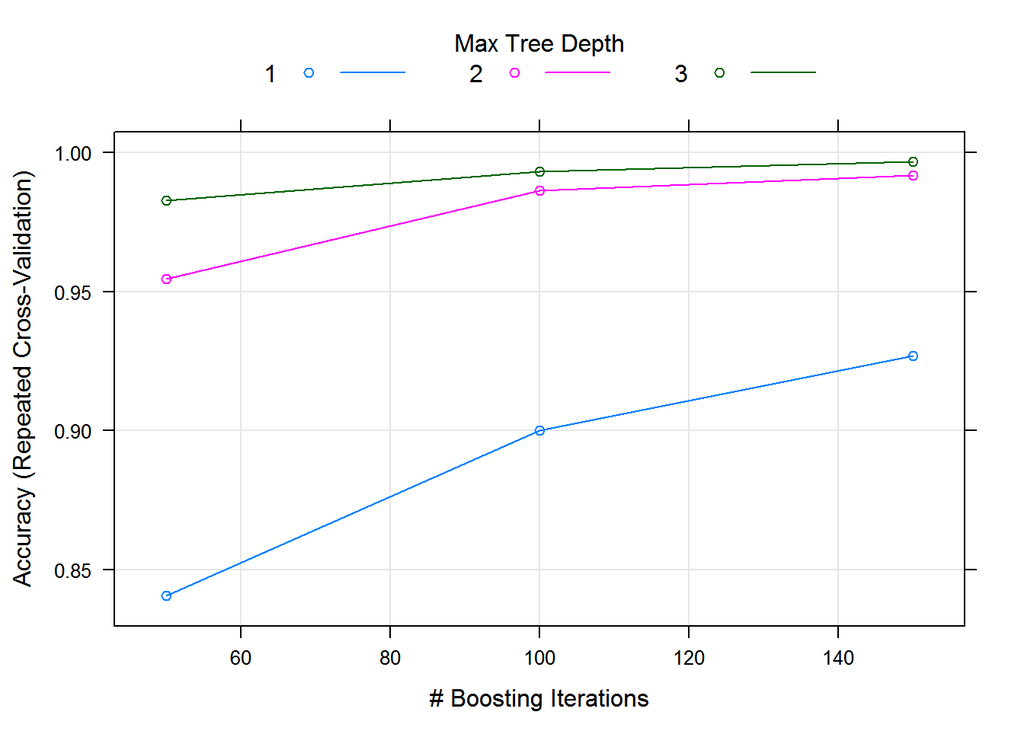

```r
plot(gbm)
```

### 4. Model based Prediction

```r
## Linear Discriminant Analysis
lda <- train(classe ~ ., data = myTraining, method = "lda", preProcess = c("center",
    "scale"))
print(lda)
```

Linear Discriminant Analysis

14718 samples 57 predictor 5 classes: ‘A’, ‘B’, ‘C’, ‘D’, ‘E’

Pre-processing: centered (79), scaled (79) Resampling: Bootstrapped (25 reps) Summary of sample sizes: 14718, 14718, 14718, 14718, 14718, 14718, … Resampling results:

Accuracy Kappa  
0.8560986 0.8181155

```r
predlda <- predict(lda, newdata = myValidation)
confusionMatrix(predlda, myValidation$classe)
```

Confusion Matrix and Statistics

```
      Reference
```

Prediction A B C D E A 1276 123 3 0 0 B 102 673 73 0 0 C 17 146 747 88 7 D 0 7 31 678 100 E 0 0 1 38 794

Overall Statistics

```
           Accuracy : 0.8499
             95% CI : (0.8396, 0.8598)
No Information Rate : 0.2845
P-Value [Acc > NIR] : < 2.2e-16

              Kappa : 0.8103
```

Mcnemar’s Test P-Value : NA

Statistics by Class:

```
                 Class: A Class: B Class: C Class: D Class: E
```

Sensitivity 0.9147 0.7092 0.8737 0.8433 0.8812 Specificity 0.9641 0.9558 0.9363 0.9663 0.9903 Pos Pred Value 0.9101 0.7936 0.7433 0.8309 0.9532 Neg Pred Value 0.9660 0.9320 0.9723 0.9692 0.9737 Prevalence 0.2845 0.1935 0.1743 0.1639 0.1837 Detection Rate 0.2602 0.1372 0.1523 0.1383 0.1619 Detection Prevalence 0.2859 0.1729 0.2049 0.1664 0.1699 Balanced Accuracy 0.9394 0.8325 0.9050 0.9048 0.9358

```r
## Naive Bayes
nb <- train(classe ~ ., data = myTraining, method = "nb", preProcess = c("center",
    "scale"))
print(nb)
```

Naive Bayes

14718 samples 57 predictor 5 classes: ‘A’, ‘B’, ‘C’, ‘D’, ‘E’

Pre-processing: centered (79), scaled (79) Resampling: Bootstrapped (25 reps) Summary of sample sizes: 14718, 14718, 14718, 14718, 14718, 14718, … Resampling results across tuning parameters:

usekernel Accuracy Kappa  
FALSE NaN NaN TRUE 0.7679656 0.7098002

Tuning parameter ‘fL’ was held constant at a value of 0 Tuning parameter ‘adjust’ was held constant at a value of 1 Accuracy was used to select the optimal model using the largest value. The final values used for the model were fL = 0, usekernel = TRUE and adjust = 1.

```r
prednb <- predict(nb, newdata = myValidation)
confusionMatrix(prednb, myValidation$classe)
```

Confusion Matrix and Statistics

```
      Reference
```

Prediction A B C D E A 1035 57 9 28 8 B 162 727 57 4 78 C 147 162 785 163 49 D 51 3 4 585 33 E 0 0 0 24 733

Overall Statistics

```
           Accuracy : 0.7881
             95% CI : (0.7764, 0.7995)
No Information Rate : 0.2845
P-Value [Acc > NIR] : < 2.2e-16

              Kappa : 0.7339
```

Mcnemar’s Test P-Value : < 2.2e-16

Statistics by Class:

```
                 Class: A Class: B Class: C Class: D Class: E
```

Sensitivity 0.7419 0.7661 0.9181 0.7276 0.8135 Specificity 0.9709 0.9239 0.8713 0.9778 0.9940 Pos Pred Value 0.9103 0.7072 0.6011 0.8654 0.9683 Neg Pred Value 0.9044 0.9427 0.9805 0.9482 0.9595 Prevalence 0.2845 0.1935 0.1743 0.1639 0.1837 Detection Rate 0.2111 0.1482 0.1601 0.1193 0.1495 Detection Prevalence 0.2319 0.2096 0.2663 0.1378 0.1544 Balanced Accuracy 0.8564 0.8450 0.8947 0.8527 0.9038

```r
myTesting <- rbind(myTraining[1, -58], myTesting)
myTesting <- myTesting[-1, ]
predict(rf, myTesting)
```

2 3 4 5 6 7 8 9 10 11 12 13 14 15 16 17 18 19 20 21 B A B A A E D B A A B C B A E E A B B B Levels: A B C D E